# Project (Assignment 3): Unsupervised Learning (E-Commerce Orders)

This notebook is your working template for **Assignment 3**.

**Note:** This assessment comprises two parts: question-guided processing/modeling (Unsupervised learning) and free-form exploration.

**Total Marks: 20**

You will:

- Continue working with the expanded dataset from Assignment 1
- Perform **clustering** to identify similar order types
- Apply **market basket analysis** (association rule mining)
- Write up findings throughout the notebook
- Publish your analysis as a github.io page

Work **top-to-bottom**. Complete each task in order before moving on.

## Submitted by

Group number on Canvas:

| Student ID (AxxxxxxxZ) | NUSNet ID (exxxxxxx) | Name (as it appears on Canvas) |
| --- | --- | --- |
| A0329571X | e1553898 | WU GUANWEI |
| A0331703R | e1582559 | YAO KAIXIANG |
| A0331520X | e1582376 | GUO MALI |
| A0331425N | e1582281 | ZHAO ZIHAN |

## Setup

Run the cell below to import the required Python packages.

```python
import pandas as pd
import numpy as np
import matplotlib.pyplot as plt
import seaborn as sns

from sklearn.model_selection import train_test_split
from sklearn.preprocessing import StandardScaler
from sklearn.cluster import KMeans

from mlxtend.preprocessing import TransactionEncoder
from mlxtend.frequent_patterns import apriori, association_rules

import warnings
warnings.filterwarnings("ignore", category=DeprecationWarning)

plt.style.use('seaborn-v0_8')
```

## Load Your Cleaned Dataset from Assignment 1

Load the cleaned and expanded dataset you created in Assignment 1 (and potentially modified in Assignment 2).

```python
# ANSWER: Load your cleaned dataset
from google.colab import drive
drive.mount('/content/drive')
df = pd.read_csv('/content/drive/MyDrive/IT5100F/assignment_1/ecommerce_orders_cleaned.csv')
```

## Task: Unsupervised Learning

### Objective

In this task, you will work on unsupervised learning and support your analysis with visualization. Perform clustering to identify **similar orders** and generate **order type recommendations** based on their characteristics. An order type cluster represents a group of orders with similar purchasing patterns, value structures, and composition.

### 1: Data Preprocessing for Unsupervised Learning [1 Mark]

Goal: Create DataFrames that contain one row per order with features suitable for both clustering and association mining.

#### 1.1 Create `all_orders_df` (one row per order)

Create a new DataFrame called `all_orders_df` with the following columns:

Identifier:

- `order_id` — Unique identifier of the order
- `basket_size` — Monetary value of the order (from `order_total_value`)
- `basket_qty` — Number of items in the order (from `num_items`)
- `freight_ratio` — Proportion of the order value that is freight (computed as `total_freight_value / order_total_value`)
- `product_diversity` — How varied the basket is in terms of product types (computed as `num_unique_products / num_items`)
- `top_product_category` — The dominant product category in the order
- `payment_type` — The payment method used
- `order_size_category` — The order size category (Small/Medium/Large)

Notes:

- `all_orders_df` must have exactly one row per `order_id`.
- No missing values should remain in these columns after preprocessing (apply reasonable handling if needed).
- Handle potential division issues appropriately (e.g., orders with zero values).
- Display the first 10 rows of `all_orders_df`, its shape, and data types.

```python
# 1.1 ANSWER: Create all_orders_df
all_orders_df = df[[
    'order_id',
    'order_total_value',
    'num_items',
    'total_freight_value',
    'num_unique_products',
    'top_product_category',
    'payment_type',
    'order_size_category'
]].copy()

all_orders_df.rename(columns={
    'order_total_value': 'basket_size',
    'num_items': 'basket_qty'}, inplace=True)


# calculate freight_ratio and handle divide by 0
all_orders_df['freight_ratio'] = np.where(
    all_orders_df['basket_size'] > 0,
    all_orders_df['total_freight_value'] / all_orders_df['basket_size'],
    0
)

# calculate product_diversity and handle divide by 0
all_orders_df['product_diversity'] = np.where(
    all_orders_df['basket_qty'] > 0,
    all_orders_df['num_unique_products'] / all_orders_df['basket_qty'],
    0
)

print("1. Shape of the DataFrame:", all_orders_df.shape)
print("\n2. Data Types:\n", all_orders_df.dtypes)
print("\n3. First 10 Rows:")
display(all_orders_df.head(10))
```

```
1. Shape of the DataFrame: (46287, 10)

2. Data Types:
 order_id                 object
basket_size             float64
basket_qty                int64
total_freight_value     float64
num_unique_products       int64
top_product_category     object
payment_type             object
order_size_category      object
freight_ratio           float64
product_diversity       float64
dtype: object

3. First 10 Rows:
```

|  | order_id | basket_size | basket_qty | total_freight_value | num_unique_products | top_product_category | payment_type | order_size_category | freight_ratio | product_diversity |
| --- | --- | --- | --- | --- | --- | --- | --- | --- | --- | --- |
| 0 | sdv-id-whzjUX | 744.312535 | 1 | 68.790159 | 1 | construction_tools_construction | voucher | Small | 0.092421 | 1.000000 |
| 1 | sdv-id-dbopoJ | 1556.667902 | 1 | 15.394619 | 1 | health_beauty | credit_card | Small | 0.009889 | 1.000000 |
| 2 | sdv-id-FSEOvM | 62.060506 | 1 | 18.751282 | 1 | luggage_accessories | debit_card | Small | 0.302145 | 1.000000 |
| 3 | sdv-id-bQcBUR | 73.873470 | 1 | 8.670875 | 1 | computers_accessories | credit_card | Small | 0.117375 | 1.000000 |
| 4 | sdv-id-MPxIXB | 361.961537 | 3 | 34.731146 | 3 | pet_shop | voucher | Medium | 0.095953 | 1.000000 |
| 5 | sdv-id-ySodbB | 867.750230 | 7 | 177.404220 | 6 | sports_leisure | voucher | Large | 0.204442 | 0.857143 |
| 6 | sdv-id-wdwBrk | 55.965822 | 2 | 15.955916 | 1 | toys | points | Small | 0.285101 | 0.500000 |
| 7 | sdv-id-maBYtk | 170.295452 | 3 | 15.205633 | 3 | computers_accessories | voucher | Medium | 0.089290 | 1.000000 |
| 8 | sdv-id-oodUXj | 83.065603 | 1 | 19.642640 | 1 | furniture_decor | voucher | Small | 0.236471 | 1.000000 |
| 9 | sdv-id-zroJIL | 98.250248 | 1 | 36.323993 | 1 | fashion_bags_accessories | points | Small | 0.369709 | 1.000000 |

#### 1.2 Create `orders_analysis_df`

- Use `train_test_split` from sklearn to split the data in `all_orders_df`.
- Set `test_size=0.3` (keep 30% of data for analysis) and `random_state=37` for reproducibility.
- Assign the **test set** to the variable `orders_analysis_df`.

Display the shape of `orders_analysis_df` and show its first 10 rows.

```python
# 1.2 ANSWER: Create orders_analysis_df using train_test_split
from sklearn.model_selection import train_test_split

# shuffle the data with a specific order
train_df, orders_analysis_df = train_test_split(
    all_orders_df,
    test_size=0.3,
    random_state=37
)


print("Shape of orders_analysis_df:", orders_analysis_df.shape)
print("First 10 rows of orders_analysis_df:")
display(orders_analysis_df.head(10))
```

```
Shape of orders_analysis_df: (13887, 10)
First 10 rows of orders_analysis_df:
```

|  | order_id | basket_size | basket_qty | total_freight_value | num_unique_products | top_product_category | payment_type | order_size_category | freight_ratio | product_diversity |
| --- | --- | --- | --- | --- | --- | --- | --- | --- | --- | --- |
| 1882 | sdv-id-ISddRn | 132.611695 | 1 | 16.746834 | 1 | christmas_supplies | voucher | Small | 0.126285 | 1.000000 |
| 40995 | sdv-id-GmlErp | 730.510053 | 6 | 54.998910 | 4 | furniture_decor | credit_card | Large | 0.075288 | 0.666667 |
| 40104 | sdv-id-BWpket | 632.486142 | 1 | 32.422233 | 1 | bed_bath_table | credit_card | Small | 0.051262 | 1.000000 |
| 25808 | sdv-id-krmbPT | 47.102393 | 1 | 11.725275 | 1 | telephony | credit_card | Small | 0.248932 | 1.000000 |
| 23294 | sdv-id-vhfMmG | 133.285008 | 1 | 18.108084 | 1 | health_beauty | debit_card | Small | 0.135860 | 1.000000 |
| 7160 | sdv-id-kcTYfM | 403.696187 | 2 | 31.918359 | 1 | auto | credit_card | Small | 0.079065 | 0.500000 |
| 7180 | sdv-id-tFFFCg | 211.465148 | 2 | 34.313026 | 2 | furniture_decor | voucher | Small | 0.162263 | 1.000000 |
| 20801 | sdv-id-KgDKAA | 57.520738 | 1 | 13.165274 | 1 | bed_bath_table | credit_card | Small | 0.228879 | 1.000000 |
| 19879 | sdv-id-cfCjEB | 576.212699 | 3 | 32.469786 | 2 | bed_bath_table | credit_card | Medium | 0.056350 | 0.666667 |
| 39874 | sdv-id-uxRZME | 141.772602 | 2 | 28.456409 | 2 | fashion_bags_accessories | credit_card | Small | 0.200719 | 1.000000 |

### 2: Determine the Optimal Number of Clusters [3 Marks]

#### 2.1 Run K-Means for Different Cluster Numbers

- Use **only the four numerical features** from `orders_analysis_df` (`basket_size`, `basket_qty`, `freight_ratio`, `product_diversity`) for clustering.
- Run K-means clustering from **k = 3 to 9** clusters.
- Important: First scale the numerical features using `StandardScaler` before fitting K-means.
- In each run, calculate the **inertia** of the cluster and store the values for each k (3 to 9) in a list or table.

Inertia is a measure of how tightly packed the clusters are. It is the sum of squared distances between each point and its assigned cluster center (centroid). Lower inertia indicates that the clusters are more compact, and the points are closer to their centroids, suggesting better clustering.

```python
# 2.1 ANSWER: Run K-means for k=3 to 9 and calculate inertia
from sklearn.cluster import KMeans
from sklearn.preprocessing import StandardScaler

# Step 1: Extract the four numerical features
numerical_features = ['basket_size', 'basket_qty', 'freight_ratio', 'product_diversity']
X = orders_analysis_df[numerical_features]

# Step 2: Scale the features using StandardScaler
scaler = StandardScaler()
X_scaled = scaler.fit_transform(X)

# Step 3: Run K-Means for k = 3 to 9 and store inertia
k_range = range(3, 10)
inertias = []

for k in k_range:
    kmeans = KMeans(n_clusters=k, random_state=37, n_init=10)
    kmeans.fit(X_scaled)
    inertias.append(kmeans.inertia_)
    print(f"k = {k}, Inertia = {kmeans.inertia_:.2f}")

# Display as a table
inertia_df = pd.DataFrame({'k': list(k_range), 'Inertia': inertias})
display(inertia_df)
```

```
k = 3, Inertia = 28884.29
k = 4, Inertia = 21464.39
k = 5, Inertia = 17303.04
k = 6, Inertia = 15013.97
k = 7, Inertia = 13219.44
k = 8, Inertia = 11762.79
k = 9, Inertia = 10516.16
```

|  | k | Inertia |
| --- | --- | --- |
| 0 | 3 | 28884.287460 |
| 1 | 4 | 21464.393895 |
| 2 | 5 | 17303.035640 |
| 3 | 6 | 15013.968444 |
| 4 | 7 | 13219.438102 |
| 5 | 8 | 11762.794068 |
| 6 | 9 | 10516.159393 |

#### 2.2 Elbow Method for Optimal Clusters

- Plot the **inertia** (y-axis) against the **number of clusters** (x-axis) to identify the optimal number of clusters using the **Elbow method**.

The Elbow Method helps in selecting the number of clusters by identifying where the inertia starts to decrease more slowly.

- Based on the Elbow plot, **choose the optimal number of clusters** and state your choice clearly.

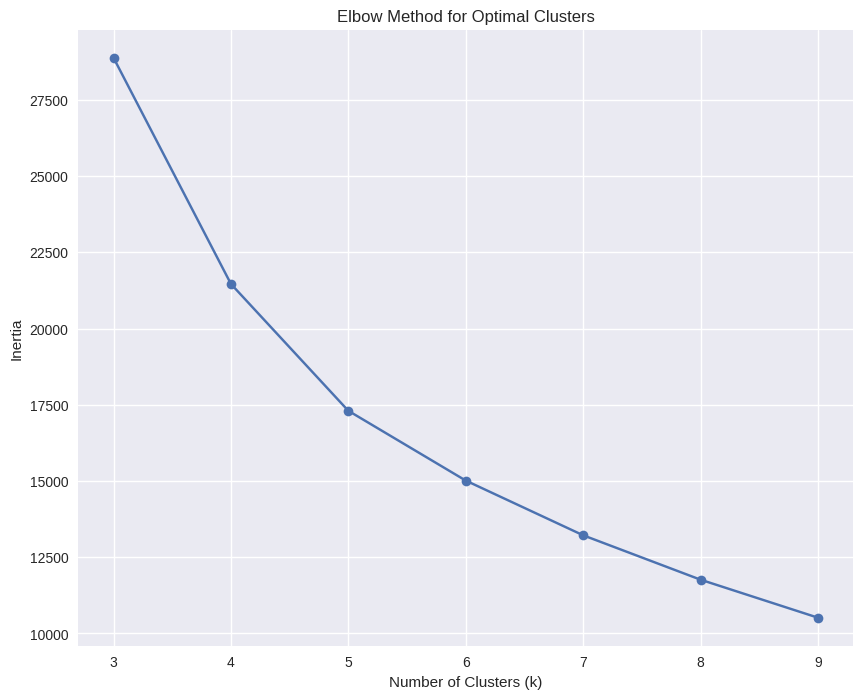

```
5 is the optimal number of clusters since the inertia decreases sharply from k=3 to k=5 (>4000 each step), but slows down noticeably afterwards to a rate of around 2000 per step.
```

```python
# 2.2 ANSWER: Create Elbow plot
plt.figure(figsize=(10, 8))
plt.plot(k_range, inertias, marker='o', linestyle='-')
plt.xlabel('Number of Clusters (k)')
plt.ylabel('Inertia')
plt.title('Elbow Method for Optimal Clusters')
plt.grid(True)
plt.show()
print("5 is the optimal number of clusters since the inertia decreases sharply from k=3 to k=5 (>4000 each step), but slows down noticeably afterwards to a rate of around 2000 per step.")
```

### 3: Cluster Analysis and Visualization [3 Marks]

#### 3.1 Identify the Cluster Number for Each Order

- Create a K-means model using the four numerical features from `all_orders_df` and the optimal number of clusters identified in Task 2.
- Fit the model on the scaled numerical features.
- Use the fitted model to assign a cluster number to each order and add a new column called `cluster` to `all_orders_df`.
- Show the first 10 rows of `all_orders_df` to verify cluster assignment.

```python
# 3.1 ANSWER: Fit K-means with optimal k and assign clusters

k = 5

# get all data
X_full = all_orders_df[numerical_features]

# use full data to train
X_scaled_full = scaler.fit_transform(X_full)
final_kmeans = KMeans(n_clusters=k, random_state=37, n_init=10)

# get cluster number by predicting
all_orders_df['cluster'] = final_kmeans.fit_predict(X_scaled_full)

display(all_orders_df.head(10))
```

|  | order_id | basket_size | basket_qty | total_freight_value | num_unique_products | top_product_category | payment_type | order_size_category | freight_ratio | product_diversity | cluster |
| --- | --- | --- | --- | --- | --- | --- | --- | --- | --- | --- | --- |
| 0 | sdv-id-whzjUX | 744.312535 | 1 | 68.790159 | 1 | construction_tools_construction | voucher | Small | 0.092421 | 1.000000 | 0 |
| 1 | sdv-id-dbopoJ | 1556.667902 | 1 | 15.394619 | 1 | health_beauty | credit_card | Small | 0.009889 | 1.000000 | 4 |
| 2 | sdv-id-FSEOvM | 62.060506 | 1 | 18.751282 | 1 | luggage_accessories | debit_card | Small | 0.302145 | 1.000000 | 3 |
| 3 | sdv-id-bQcBUR | 73.873470 | 1 | 8.670875 | 1 | computers_accessories | credit_card | Small | 0.117375 | 1.000000 | 0 |
| 4 | sdv-id-MPxIXB | 361.961537 | 3 | 34.731146 | 3 | pet_shop | voucher | Medium | 0.095953 | 1.000000 | 0 |
| 5 | sdv-id-ySodbB | 867.750230 | 7 | 177.404220 | 6 | sports_leisure | voucher | Large | 0.204442 | 0.857143 | 2 |
| 6 | sdv-id-wdwBrk | 55.965822 | 2 | 15.955916 | 1 | toys | points | Small | 0.285101 | 0.500000 | 1 |
| 7 | sdv-id-maBYtk | 170.295452 | 3 | 15.205633 | 3 | computers_accessories | voucher | Medium | 0.089290 | 1.000000 | 0 |
| 8 | sdv-id-oodUXj | 83.065603 | 1 | 19.642640 | 1 | furniture_decor | voucher | Small | 0.236471 | 1.000000 | 3 |
| 9 | sdv-id-zroJIL | 98.250248 | 1 | 36.323993 | 1 | fashion_bags_accessories | points | Small | 0.369709 | 1.000000 | 3 |

#### 3.2 Visualize the Clusters

Create two visualizations to understand your clusters:

- **Visualization 1: Cluster Profile Heatmap**
  - Visualize the cluster profiles using a heatmap to understand the average characteristics of each segment.
  - Step 1: Compute the mean of the four numerical features (`basket_size`, `basket_qty`, `freight_ratio`, `product_diversity`) for each cluster.
  - Step 2: Scale these means (e.g., using `StandardScaler` to calculate Z-scores) so that different units (price vs. count) can be compared directly.
  - Step 3: Plot the scaled means as a heatmap:
    - X-axis: Cluster number
    - Y-axis: Feature name
    - Color: Use a diverging colormap (e.g., `RdBu_r`) to distinguish features that are above average (positive Z-score) from those that are below average (negative Z-score)
    - Annotation: Display the Z-score values in each cell
  - Add a clear title.
- **Visualization 2: Cluster Size Distribution**
  - Create a bar chart showing the number of orders in each cluster.
    - X-axis: Cluster number (0, 1, 2, ...)
    - Y-axis: Count of orders
    - This helps you understand if clusters are balanced or if some clusters dominate.
  - Add a title and axis labels.

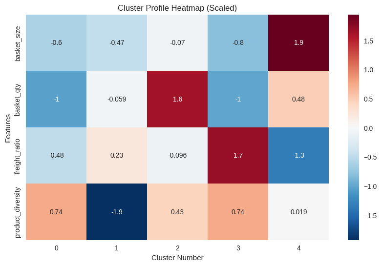

```python
# 3.2 ANSWER: Visualization 1 - Cluster profile heatmap
# calculate the mean of 4 attributes
cluster_profiles = all_orders_df.groupby('cluster')[numerical_features].mean()

scaled_profiles = pd.DataFrame(
    scaler.fit_transform(cluster_profiles),
    index=cluster_profiles.index,
    columns=cluster_profiles.columns
).T

# draw
plt.figure(figsize=(10, 6))
sns.heatmap(scaled_profiles, annot=True, cmap='RdBu_r', center=0)
plt.title('Cluster Profile Heatmap (Scaled)')
plt.xlabel('Cluster Number')
plt.ylabel('Features')
plt.show()
```

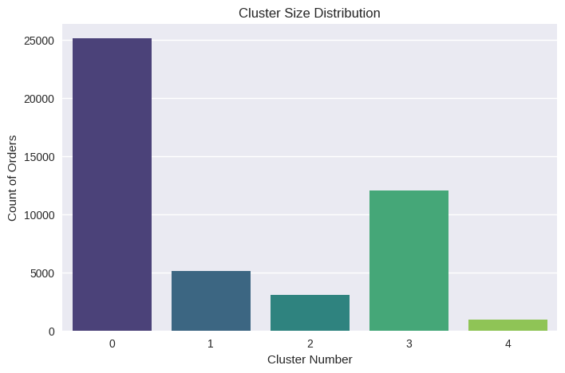

```python
# 3.2 ANSWER: Visualization 2 - Cluster size distribution

plt.figure(figsize=(8, 5))
sns.countplot(data=all_orders_df, x='cluster', palette='viridis')
plt.title('Cluster Size Distribution')
plt.xlabel('Cluster Number')
plt.ylabel('Count of Orders')
plt.show()
```

**Briefly comment (2-3 sentences) on:**

- How well separated do the clusters appear based on the heatmap?
- Which features seem to have the most significant impact on defining the clusters? Why might this be the case?
- Based on the visualizations that you have generated, comment on the nature of the clusters and what it implies for an e-commerce business

### 4: Market Basket Analysis (Association Rule Mining) [8 Marks]

#### 4.1 Context: What is Market Basket Analysis?

Market Basket Analysis is an unsupervised learning technique that identifies which products, categories, or attributes are frequently observed together. In e-commerce, this helps answer questions such as:

- "Which payment methods are preferred for which product categories?"
- "Do certain order sizes correlate with specific product types?"
- "What are the multi-dimensional patterns across category, payment, and order size?"

Association rules are commonly described using three key metrics:

- **Support**: How frequently a pattern occurs (0-1 scale)
- **Confidence**: Likelihood of the consequent given the antecedent (0-1 scale)
- **Lift**: How much more likely the rule is compared to random chance (> 1 indicates a positive association)

The Apriori algorithm discovers frequent itemsets and then generates association rules from them.

In this task, you will perform Market Basket Analysis using the categorical features from `all_orders_df` to discover multi-dimensional associations between product category, payment type, and order size category.

#### 4.2 Prepare Transaction Data [1 Mark]

Convert each order in `all_orders_df` into a simple "basket" representation.

Create a Python list called `transactions`, where each element represents one order and contains exactly three string items constructed from that order:

- `cat_{top_product_category}` (e.g., `cat_electronics`, `cat_furniture_decor`)
- `pay_{payment_type}` (e.g., `pay_credit_card`, `pay_boleto`)
- `size_{order_size_category}` (e.g., `size_Small`, `size_Large`)

After constructing `transactions`, display the first 5 transactions to verify the format.

```python
# 4.2 ANSWER: Create transaction list
transactions = []

for _, row in all_orders_df.iterrows():
    category_item = f"cat_{row['top_product_category'].lower().replace(' ', '_')}"
    payment_item = f"pay_{row['payment_type'].lower().replace(' ', '_')}"
    size_item = f"size_{row['order_size_category']}"

    transaction = [category_item, payment_item, size_item]
    transactions.append(transaction)

print("=== First 5 Transaction Examples ===")
for i in range(5):
    print(f"Order {i+1}: {transactions[i]}")

print(f"\nTotal number of transactions: {len(transactions)}")
print(f"Total number of orders: {len(all_orders_df)}")
print(f"Transaction count matches order count: {len(transactions) == len(all_orders_df)}")
```

```
=== First 5 Transaction Examples ===
Order 1: ['cat_construction_tools_construction', 'pay_voucher', 'size_Small']
Order 2: ['cat_health_beauty', 'pay_credit_card', 'size_Small']
Order 3: ['cat_luggage_accessories', 'pay_debit_card', 'size_Small']
Order 4: ['cat_computers_accessories', 'pay_credit_card', 'size_Small']
Order 5: ['cat_pet_shop', 'pay_voucher', 'size_Medium']

Total number of transactions: 46287
Total number of orders: 46287
Transaction count matches order count: True
```

#### 4.3 Encode Transactions and Apply Apriori Algorithm [2 Marks]

Use the `mlxtend` library to discover frequent itemsets and generate association rules.

- Step 1: Encode transactions using `TransactionEncoder` and display the shape of the encoded DataFrame.
- Step 2: Apply `apriori()` with `min_support = 0.01` and `use_colnames = True`, then display the number of frequent itemsets found.
- Step 3: Generate association rules using `association_rules()` with `metric = 'lift'` and `min_threshold = 1.0`, then display the number of rules generated.

```python
# 4.3 ANSWER: Step 1 - Encode transactions
te = TransactionEncoder()
te_array = te.fit(transactions).transform(transactions)
encoded_df = pd.DataFrame(te_array, columns=te.columns_)

print(f"=== Encoded Data Information ===")
print(f"Encoded DataFrame shape: {encoded_df.shape}")
print(f"Number of unique transaction items: {len(te.columns_)}")
print("\nFirst 5 rows of encoded data:")
display(encoded_df.head())
```

```
=== Encoded Data Information ===
Encoded DataFrame shape: (46287, 79)
Number of unique transaction items: 79

First 5 rows of encoded data:
```

|  | cat_agro_industry_and_commerce | cat_air_conditioning | cat_art | cat_arts_and_craftmanship | cat_audio | cat_auto | cat_baby | cat_bed_bath_table | cat_books_general_interest | cat_books_imported | ... | cat_toys | cat_watches_gifts | pay_credit_card | pay_debit_card | pay_not_defined | pay_points | pay_voucher | size_Large | size_Medium | size_Small |
| --- | --- | --- | --- | --- | --- | --- | --- | --- | --- | --- | --- | --- | --- | --- | --- | --- | --- | --- | --- | --- | --- |
| 0 | False | False | False | False | False | False | False | False | False | False | ... | False | False | False | False | False | False | True | False | False | True |
| 1 | False | False | False | False | False | False | False | False | False | False | ... | False | False | True | False | False | False | False | False | False | True |
| 2 | False | False | False | False | False | False | False | False | False | False | ... | False | False | False | True | False | False | False | False | False | True |
| 3 | False | False | False | False | False | False | False | False | False | False | ... | False | False | True | False | False | False | False | False | False | True |
| 4 | False | False | False | False | False | False | False | False | False | False | ... | False | False | False | False | False | False | True | False | True | False |

5 rows × 79 columns

```python
# 4.3 ANSWER: Step 2 - Apply Apriori
min_support = 0.01

frequent_itemsets = apriori(
    encoded_df,
    min_support=min_support,
    use_colnames=True
)

print(f"\n=== Apriori Algorithm Results ===")
print(f"Minimum support = {min_support}")
print(f"Number of frequent itemsets found: {len(frequent_itemsets)}")

print("\nFirst 10 frequent itemsets:")
display(frequent_itemsets.head(10))
```

```
=== Apriori Algorithm Results ===
Minimum support = 0.01
Number of frequent itemsets found: 102

First 10 frequent itemsets:
```

|  | support | itemsets |
| --- | --- | --- |
| 0 | 0.030592 | (cat_auto) |
| 1 | 0.023592 | (cat_baby) |
| 2 | 0.138678 | (cat_bed_bath_table) |
| 3 | 0.073152 | (cat_computers_accessories) |
| 4 | 0.016311 | (cat_consoles_games) |
| 5 | 0.011126 | (cat_construction_tools_construction) |
| 6 | 0.027740 | (cat_cool_stuff) |
| 7 | 0.016916 | (cat_electronics) |
| 8 | 0.030419 | (cat_fashion_bags_accessories) |
| 9 | 0.073736 | (cat_furniture_decor) |

```python
# 4.3 ANSWER: Step 3 - Generate association rules
rules = association_rules(
    frequent_itemsets,
    metric="lift",
    min_threshold=1.0
)

print(f"\n=== Association Rules Results ===")
print(f"Number of association rules generated (lift ≥ 1.0): {len(rules)}")

print("\nFirst 5 association rules:")
display(rules[['antecedents', 'consequents', 'support', 'confidence', 'lift']].head())
```

```
=== Association Rules Results ===
Number of association rules generated (lift ≥ 1.0): 138

First 5 association rules:
```

|  | antecedents | consequents | support | confidence | lift |
| --- | --- | --- | --- | --- | --- |
| 0 | (pay_credit_card) | (cat_auto) | 0.020503 | 0.033909 | 1.108423 |
| 1 | (cat_auto) | (pay_credit_card) | 0.020503 | 0.670198 | 1.108423 |
| 2 | (pay_credit_card) | (cat_baby) | 0.015015 | 0.024833 | 1.052604 |
| 3 | (cat_baby) | (pay_credit_card) | 0.015015 | 0.636447 | 1.052604 |
| 4 | (size_Small) | (cat_baby) | 0.020913 | 0.024184 | 1.025108 |

#### 4.4 Extract and Display Top 10 Rules [1 Mark]

Sort the association rules by **lift** in descending order and display the top 10 rules in a table showing:

- Antecedents (left-hand side of rule)
- Consequents (right-hand side of rule)
- Support
- Confidence
- Lift

Example rule output and interpretation:

| antecedents | consequents | support | confidence | lift |
| --- | --- | --- | --- | --- |
| (cat_furniture_decor, size_Large) | (pay_credit_card) | 0.042 | 0.756 | 1.84 |

"Customers who purchase **furniture** in **large orders** have a **75.6% probability** (confidence) of paying with a **credit card**. This behavior is **1.84 times more likely** (lift) than the general probability of using a credit card.

```python
# 4.4 ANSWER: Display top 10 rules by lift
rules_sorted = rules.sort_values(by='lift', ascending=False)
top_10_rules = rules_sorted[['antecedents', 'consequents', 'support', 'confidence', 'lift']].head(10)

pd.options.display.float_format = '{:.3f}'.format

print("=== Top 10 Association Rules (Sorted by Lift Descending) ===")
display(top_10_rules)

pd.reset_option('display.float_format')

print("\n=== Rule Interpretation Example ===")
top_rule = top_10_rules.iloc[0]
antecedents = ', '.join(list(top_rule['antecedents']))
consequents = ', '.join(list(top_rule['consequents']))

print(f"""
Rule 1 Interpretation:
- Antecedents: {antecedents}
- Consequents: {consequents}
- Support: {top_rule['support']:.3f} → This combination appears in {top_rule['support']*100:.1f}% of orders
- Confidence: {top_rule['confidence']:.3f} → {top_rule['confidence']*100:.1f}% of customers who purchase {antecedents} choose {consequents}
- Lift: {top_rule['lift']:.2f} → This association is {top_rule['lift']:.2f} times more likely to occur than by random chance
""")
```

```
=== Top 10 Association Rules (Sorted by Lift Descending) ===
```

|  | antecedents | consequents | support | confidence | lift |
| --- | --- | --- | --- | --- | --- |
| 24 | (cat_furniture_decor) | (size_Large) | 0.015 | 0.198 | 5.328 |
| 25 | (size_Large) | (cat_furniture_decor) | 0.015 | 0.393 | 5.328 |
| 77 | (cat_bed_bath_table) | (pay_credit_card, size_Medium) | 0.017 | 0.122 | 2.023 |
| 72 | (pay_credit_card, size_Medium) | (cat_bed_bath_table) | 0.017 | 0.281 | 2.023 |
| 76 | (size_Medium) | (pay_credit_card, cat_bed_bath_table) | 0.017 | 0.172 | 1.757 |
| 73 | (pay_credit_card, cat_bed_bath_table) | (size_Medium) | 0.017 | 0.172 | 1.757 |
| 26 | (cat_furniture_decor) | (size_Medium) | 0.013 | 0.172 | 1.749 |
| 27 | (size_Medium) | (cat_furniture_decor) | 0.013 | 0.129 | 1.749 |
| 9 | (cat_bed_bath_table) | (size_Medium) | 0.023 | 0.164 | 1.671 |
| 8 | (size_Medium) | (cat_bed_bath_table) | 0.023 | 0.232 | 1.671 |

```
=== Rule Interpretation Example ===

Rule 1 Interpretation:
- Antecedents: cat_furniture_decor
- Consequents: size_Large
- Support: 0.015 → This combination appears in 1.5% of orders
- Confidence: 0.198 → 19.8% of customers who purchase cat_furniture_decor choose size_Large
- Lift: 5.33 → This association is 5.33 times more likely to occur than by random chance
```

#### 4.5 Interpretation (3-4 sentences) [3 Marks]

Write a brief interpretation explaining:

- What the top 3 unique rules tell you about customer behavior
- Which combinations are most strongly associated (highest lift)
- Why these associations might exist (business intuition)
- Change the min_support value to 0.005 and 0.3 and comment on any changes in the rules identified

```python
def run_apriori_with_different_support(min_support_val):
    fi = apriori(encoded_df, min_support=min_support_val, use_colnames=True)
    r = association_rules(fi, metric="lift", min_threshold=1.0)
    return len(fi), len(r)

fi_0005, rules_0005 = run_apriori_with_different_support(0.005)
fi_03, rules_03 = run_apriori_with_different_support(0.3)

top_3_rules = top_10_rules.head(3)

print(top_3_rules)
```

```
              antecedents                     consequents   support  \
24  (cat_furniture_decor)                    (size_Large)  0.014583
25           (size_Large)           (cat_furniture_decor)  0.014583
77   (cat_bed_bath_table)  (pay_credit_card, size_Medium)  0.016851

    confidence      lift
24    0.197773  5.328480
25    0.392899  5.328480
77    0.121514  2.023212
```

**4.5 ANSWER:**

1.Customer Behavior from Top 3 Rules

Rule 1 (size_Large → cat_furniture_decor): 39.3% of large orders are for furniture/decor, showing customers buy these high-value, bulky items in bulk.

Rule 2 (cat_furniture_decor → size_Large): 19.8% of furniture/decor purchases are large orders (mirroring Rule 1, confirming furniture/decor’s link to high-value transactions).

Rule 3 (size_Medium + pay_credit_card → cat_bed_bath_table): 28.1% of medium orders paid by credit card are for bed/bath/table goods, indicating credit cards are preferred for mid-value household purchases.

2.Strongest AssociationThe bidirectional link between size_Large and cat_furniture_decor (lift=5.33) is the strongest, which is far above the "very strong" threshold of 2.0.

3.Business Rationale for AssociationsFurniture/decor are high-ticket, bulky items that naturally form large orders; credit cards are favored for mid-value household goods due to installment options and rewards.

4.Impact of Changing min_support

#### 4.6 Business Recommendations (2-3 bullet points) [1 Mark]

Based on the discovered associations, provide actionable business recommendations for an e-commerce firm.

**4.6 ANSWER:**

-For associations between different payment methods and product categories: Prioritize displaying the preferred payment methods for each product category on product detail pages to simplify the payment process and reduce cart abandonment rates.

#### Tips

- Rules with **lift > 1.5** are considered strong associations; rules with **lift > 2.0** are very strong.
- When writing interpretations, explain not just the statistical strength but also the **business logic** behind the patterns.

## Task: Report (5 Marks)

### Objective

(Note: No separate report submission is required.) The report comprises the write-up that you have been working on within this iPython notebook. The write-up/report should clearly describe the steps performed and the reasoning behind each processing done for all the tasks from Assignment 1 until Association mining above.

### 1: Write-up / Report

Describe the steps performed and the reasoning behind each processing step for all tasks you have worked on so far:

- Assignment 1 (data cleaning and preprocessing)
- Assignment 2 (supervised learning)
- Assignment 3 (unsupervised learning)

Include your explanations inline near the cells where processing is done, and keep your descriptions concise but clear. Connect each analysis step to business objectives where appropriate.

Report

Assignment 1: Data Preprocessing and EDA

The goal of our Assignment 1 was to clean, integrate, and prepare the raw e‑commerce data for later analysis.

First, we loaded and merged four datasets using inner joins on order_id to ensure only complete orders were kept. Missing numerical values were filled using the median, and missing categorical values were filled using the mode. Invalid records such as non‑positive order values or item counts were removed to ensure data quality.

New features were created to support business analysis, including order_value_per_item and order_size_category. Sanity checks were applied to ensure logical consistency, such as ensuring the number of items is at least the number of unique products.

Finally, our exploratory data analysis was performed using bar charts and box plots to understand order distributions, product category popularity, and relationships between order value and number of items. This step ensured the dataset was reliable, consistent, and ready for modelling.

Assignment 2: Supervised Learning

In Assignment 2, the objective was to build classification models to predict payment_type using order characteristics.

The cleaned dataset from Assignment 1 was split into training and test sets to allow fair evaluation of model performance. Categorical variables were label‑encoded, and numerical features were standardised because models such as logistic regression and SVM are sensitive to feature scales.

Three models were trained: Logistic Regression, Decision Tree, and SVM. They were evaluated using accuracy, precision, recall, and F1‑score. Logistic Regression was selected as the best model because it achieved the highest F1‑score, was less affected by class imbalance, and was highly interpretable and efficient for real‑world deployment. This part of the project showed that simple, stable models perform best for payment method prediction in this e‑commerce dataset.

Assignment 3: Unsupervised Learning

Assignment 3 focused on clustering and market basket analysis to discover customer behaviour patterns.

First, a new dataset was created with customer‑centric features such as basket_size, freight_ratio, and product_diversity. K‑Means clustering was applied, and the elbow method was used to select five clusters.

The clusters were visualised using heatmaps and bar charts to identify distinct customer segments, such as high‑value orders and small regular orders.

Next, association rule mining was performed using the Apriori algorithm. Orders were converted into transactions containing product category, payment type, and order size. Rules were generated with a minimum support of 0.01. The top rules showed strong associations, particularly between large orders and furniture/decor products.

Overall Summary

Our three assignments together form a complete analytics pipeline. Assignment 1 built a clean data foundation. Assignment 2 developed a predictive model for customer payment behaviour.Assignment 3 uncovered customer segments and strong purchasing patterns.

All the steps were designed to support practical e‑commerce business decisions including inventory management, marketing, checkout experience optimisation, and revenue improvement.

### 2: Publish the Report

Publish the report as a read-only github.io static page.

- Note: this differs from setting up a GitHub repository with your iPython notebook in it.
- Convert your notebook to HTML and host it on GitHub Pages (e.g., using nbconvert or Jupyter Book).

Ensure the page is publicly accessible and provide the URL in your Canvas submission.

**Your published URL:**

https://functionykx.github.io/IT5100F/T5100F_Assignment_3_Template.html

```python
!pip install nbconvert
!jupyter nbconvert --to html "/content/drive/MyDrive/IT5100F/assignment_1/T5100F_Assignment_3_Template.ipynb"
```

```
[NbConvertApp] Converting notebook /content/drive/MyDrive/IT5100F/assignment_1/T5100F_Assignment_3_Template.ipynb to html
[NbConvertApp] Writing 358565 bytes to /content/drive/MyDrive/IT5100F/assignment_1/T5100F_Assignment_3_Template.html
```

# End of Assignment 3

**Before submission, ensure:**

1. All code cells execute without errors
2. All markdown cells contain your written explanations
3. Visualizations are clear and properly labeled
4. Your notebook tells a coherent story from start to finish
5. Your github.io page is published and URL is provided

**Good luck!**